# Josephine_WIP

Josephine Wright

2026-03-08

```r
library(tidyverse)
library(janitor)
```

```r
library(RColorBrewer)
library(ggplot2)
library(paletteer)
library(ggmap)
library(patchwork)
library(ggdensity)
library(paletteer)
library(RColorBrewer)
```

```r
setwd("~/Desktop/BIS15L_W2026_Group-8/rbird")
```

Data

```r
sample_data <- read_csv("sample_data.csv") %>%
  clean_names()
species_data <- read_csv("species_data.csv") %>%
  clean_names()
total_data <- read_csv("total_data.csv") %>%
  clean_names()
```

Removing data from total_data where the only information is sampling_event_identifier

```r
#total_data <- total_data %>%
#  filter(!is.na(common_name))
```

How many bird species are represented by the data?

```r
total_data %>%
  distinct(common_name) %>%
  count()
```

```
## # A tibble: 1 × 1
##       n
##   <int>
## 1   395
```

Top five bird observations between 2019 and 2021 (total)

```r
top_five_total <- total_data %>%
  filter(year_y %in% c(2019, 2020, 2021)) %>%
  group_by(common_name) %>%
  summarise(count = n()) %>%
  arrange(desc(count)) %>%
  slice_head(n = 5)
top_five_total
```

```
## # A tibble: 5 × 2
##   common_name           count
##   <chr>                 <int>
## 1 Black Phoebe          17705
## 2 House Finch           14295
## 3 Mourning Dove         13683
## 4 California Scrub-Jay  13598
## 5 White-crowned Sparrow 12009
```

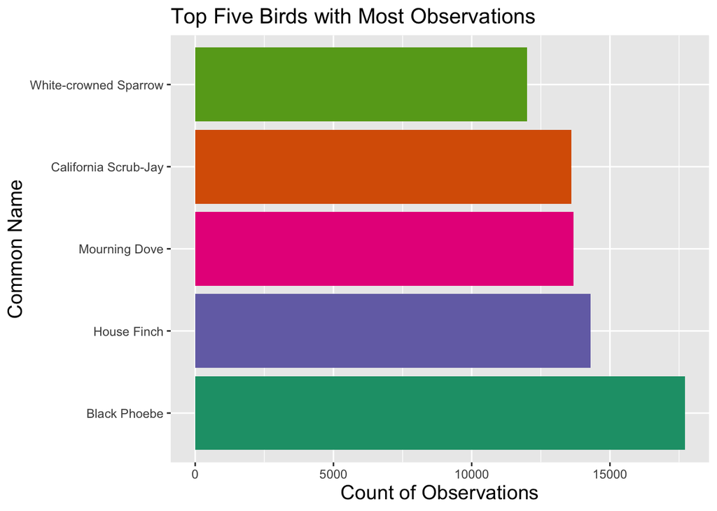

```r
top_five_total %>%
ggplot(aes(x = common_name, y = count, fill = common_name)) +
  geom_bar(stat = "identity") +
  coord_flip()+
  scale_fill_brewer(palette = "Dark2")+
  labs(title = "Top Five Birds with Most Observations",
       x = "Common Name",
       y = "Count of Observations",
       fill="Common Name") +
  theme(plot.title = element_text(size = 15),
        axis.title.x = element_text(size = 14),
        axis.title.y = element_text(size = 14),
        legend.position = "none")+
  scale_x_discrete(limits = top_five_total$common_name)
```

Top five birds with most observations per each year

```r
top_five <- total_data %>%
  filter(year_y %in% c(2019, 2020, 2021)) %>%
  group_by(year_y, common_name) %>%
  summarise(count = n()) %>%
  arrange(desc(count)) %>%
  slice_head(n = 5)
top_five
```

```
## # A tibble: 15 × 3
## # Groups:   year_y [3]
##    year_y common_name           count
##     <dbl> <chr>                 <int>
##  1   2019 Black Phoebe           6040
##  2   2019 Mourning Dove          4594
##  3   2019 House Finch            4532
##  4   2019 California Scrub-Jay   4483
##  5   2019 Mallard                4060
##  6   2020 Black Phoebe           5798
##  7   2020 House Finch            4842
##  8   2020 Mourning Dove          4476
##  9   2020 California Scrub-Jay   4451
## 10   2020 White-crowned Sparrow  4139
## 11   2021 Black Phoebe           5867
## 12   2021 House Finch            4921
## 13   2021 California Scrub-Jay   4664
## 14   2021 Mourning Dove          4613
## 15   2021 White-crowned Sparrow  4136
```

Yellow-rumped Warbler 2019 (to readjust battle)

```r
total_data %>%
  filter(year_y=="2019", common_name=="Yellow-rumped Warbler") %>%
  count()
```

```
## # A tibble: 1 × 1
##       n
##   <int>
## 1  3943
```

White-crowned Sparrow 2019 & 2019+2020 (to readjust battle)

```r
total_data %>%
  filter(year_y=="2019", common_name=="White-crowned Sparrow") %>%
  count()
```

```
## # A tibble: 1 × 1
##       n
##   <int>
## 1  3734
```

```r
total_data %>%
  filter(year_y %in% c(2019, 2020), common_name=="White-crowned Sparrow") %>%
  count()
```

```
## # A tibble: 1 × 1
##       n
##   <int>
## 1  7873
```

Finding totals as years stack

```r
top_observations_19 <- total_data %>%
  filter(year_y=="2019") %>%
  group_by(common_name) %>%
  summarise(count = n()) %>%
  arrange(desc(count)) %>%
  slice_head(n = 5)
top_observations_19
```

```
## # A tibble: 5 × 2
##   common_name          count
##   <chr>                <int>
## 1 Black Phoebe          6040
## 2 Mourning Dove         4594
## 3 House Finch           4532
## 4 California Scrub-Jay  4483
## 5 Mallard               4060
```

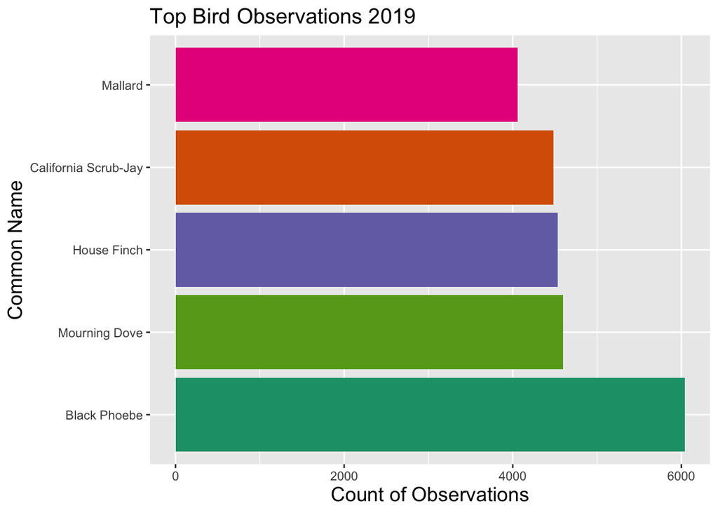

```r
top_observations_19 %>%
  ggplot(aes(x = common_name, y = count, fill = common_name)) +
  geom_bar(stat = "identity") +
  coord_flip()+
  scale_fill_brewer(palette = "Dark2")+
  labs(title = "Top Bird Observations 2019",
       x = "Common Name",
       y = "Count of Observations",
       fill="Common Name") +
  theme(plot.title = element_text(size = 15),
        axis.title.x = element_text(size = 14),
        axis.title.y = element_text(size = 14),
        legend.position = "none")+
  scale_x_discrete(limits = top_observations_19$common_name)
```

```r
top_observations_19_20 <- total_data %>%
  filter(year_y %in% c(2019, 2020)) %>%
  group_by(common_name) %>%
  summarise(count = n()) %>%
  arrange(desc(count)) %>%
  slice_head(n = 5)
top_observations_19_20
```

```
## # A tibble: 5 × 2
##   common_name           count
##   <chr>                 <int>
## 1 Black Phoebe          11838
## 2 House Finch            9374
## 3 Mourning Dove          9070
## 4 California Scrub-Jay   8934
## 5 Yellow-rumped Warbler  7911
```

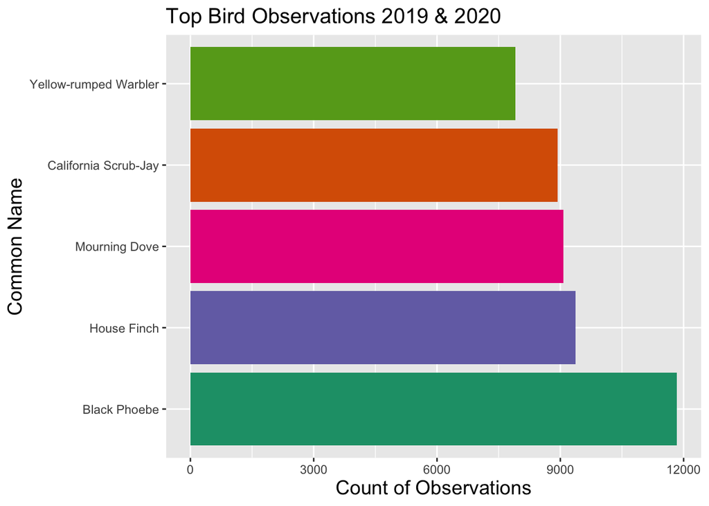

```r
top_observations_19_20 %>%
  ggplot(aes(x = common_name, y = count, fill = common_name)) +
  geom_bar(stat = "identity") +
  coord_flip()+
  scale_fill_brewer(palette = "Dark2")+
  labs(title = "Top Bird Observations 2019 & 2020",
       x = "Common Name",
       y = "Count of Observations",
       fill="Common Name") +
  theme(plot.title = element_text(size = 15),
        axis.title.x = element_text(size = 14),
        axis.title.y = element_text(size = 14),
        legend.position = "none")+
  scale_x_discrete(limits = top_observations_19_20$common_name)
```

```r
top_observations_19_20_21 <- total_data %>%
  filter(year_y %in% c(2019, 2020, 2021)) %>%
  group_by(common_name) %>%
  summarise(count = n()) %>%
  arrange(desc(count)) %>%
  slice_head(n = 5)
top_observations_19_20_21
```

```
## # A tibble: 5 × 2
##   common_name           count
##   <chr>                 <int>
## 1 Black Phoebe          17705
## 2 House Finch           14295
## 3 Mourning Dove         13683
## 4 California Scrub-Jay  13598
## 5 White-crowned Sparrow 12009
```

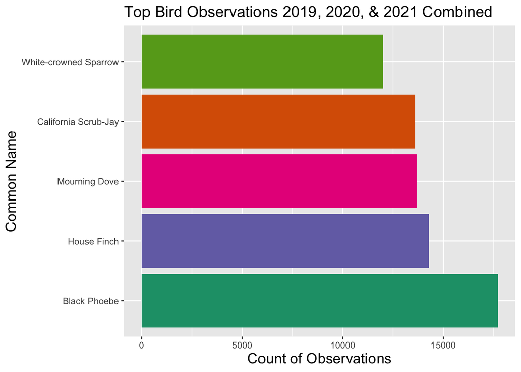

```r
top_observations_19_20_21 %>%
  ggplot(aes(x = common_name, y = count, fill = common_name)) +
  geom_bar(stat = "identity") +
  coord_flip()+
  scale_fill_brewer(palette = "Dark2")+
  labs(title = "Top Bird Observations 2019, 2020, & 2021 Combined",
       x = "Common Name",
       y = "Count of Observations",
       fill="Common Name") +
  theme(plot.title = element_text(size = 15),
        axis.title.x = element_text(size = 14),
        axis.title.y = element_text(size = 14),
        legend.position = "none")+
  scale_x_discrete(limits = top_observations_19_20_21$common_name)
```

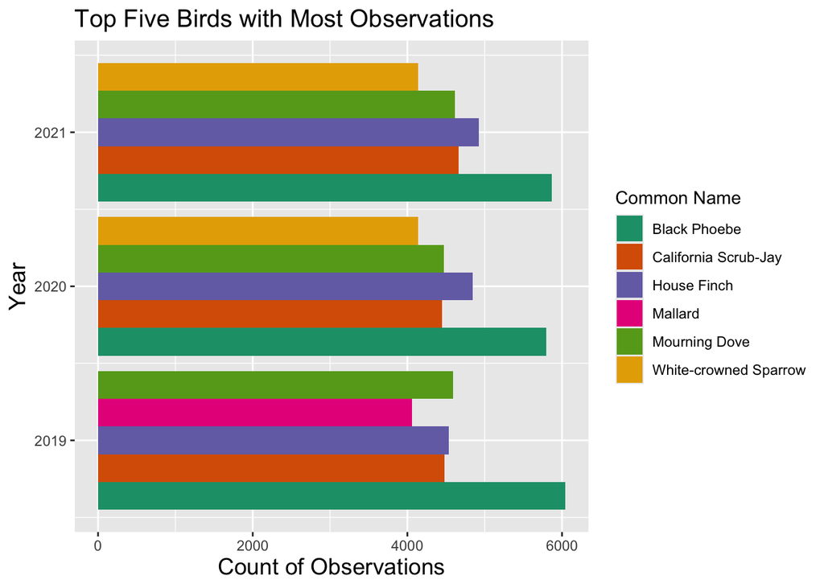

```r
top_five %>%
  ggplot(aes(x = year_y, y = count, fill = common_name)) +
  geom_bar(stat = "identity", position = "dodge") +
  coord_flip()+
  scale_fill_brewer(palette = "Dark2")+
  labs(title = "Top Five Birds with Most Observations",
       x = "Year",
       y = "Count of Observations",
       fill="Common Name") +
  theme(plot.title = element_text(size = 15),
        axis.title.x = element_text(size = 14),
        axis.title.y = element_text(size = 14))
```

Shiny Questions -

**What is your favourite season? (Winter, Spring, Summer, Fall)** Do you prefer when people go the extra mile for you, would you rather meet them halfway, or do you like when others do all the work? (effort_distance_km_y >= 1, effort_distance_km<= 1, effort_distance_km == NA (or 0)) **Do you prefer to be around a lot of people or do you like to keep to yourself? (number_observers_y >= 5)** Where is your favourite place to hang out in Davis? (different hotspots - not sure this will work though, need distinctly varying birds per hotspot)